# Convergence speed

#### 5

$$ x, y<1 \text { или } x, y \geq 2 $$$$ (y-x)^{2} \leq(25 y-25 x)(y-x) \leq 25(y-x)^{2}-\text { тоже верно } $$

Показали, что константа Липшица: $L = 25$, а константа сильной выпуклости $\mu = 1 $

Реализуем метод тяжёлого шарика Поляка

$$ x_{k+1}=x_{k}-\alpha \nabla f\left(x_{k}\right)+\beta\left(x_{k}-x_{k-1}\right) $$

```python
def Momentum_SGD(f, df, x0, alpha, beta, Nsteps):
    x_1 = x0
    x_2 = x0
    x_new = x0
    hist = []
    X = []
    for i in range(Nsteps):
        hist.append(f(x_new))
        X.append(x_new)
        x_new = x_2 - alpha * df(x_2) + beta*(x_2 - x_1)
        x_1 = x_2
        x_2 = x_new
    return hist, x_new, X
```

```python
def f(x):
    if x < 1:
        return 25*x**2/2
    elif 1 <= x < 2:
        return 24*x + 0.5*x**2
    else:
        return 25*x**2/2 - 24*x
```

```python
def df(x):
    if x < 1:
        return 25*x
    elif 1 <= x < 2:
        return 24 + x
    else:
        return 25*x - 24
```

```python
L = 25
m = 1
```

```python
hist, x_opt, X = Momentum_SGD(f, df, x0=3.1, alpha=1/L, beta=0.1, Nsteps=10)
```

```
x* = 2.6304059999999995e-05
```

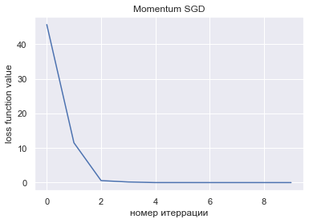

```python
plt.plot(range(len(hist)), hist)
plt.xlabel('номер итеррации')
plt.ylabel('loss function value')
plt.title(f'Momentum SGD')
print(f"x* = {x_opt}")
```

Посмотрим на нашу функцию

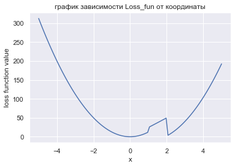

```python
Loss = []
for x in np.linspace(-5, 5, 100):
    Loss.append(f(x))
plt.plot(np.linspace(-5, 5, 100), Loss)
plt.xlabel('x')
plt.ylabel('loss function value')
plt.title(f'график зависимости Loss_fun от координаты')
```

У неё глобальный минимум в 0, но есть ещё и локальный в точке x = 2.

Поподбираем гиперпараметры: зафиксируем $\alpha$ и точку старта. Возьмём её правее 2 (локального минимума) и посмотрим, как значение $\beta$ будет влиять на сходимость (при $\beta = 0$ мы получим обычный градиентый спуск). $\alpha$ возьмём 1/L, так как тогда у градиентного спуска найлучшая скорость сходимости

```
0.0
0.001273118719999999
0.051104317440000005
0.24012562268159954
-0.7125725347839998
```

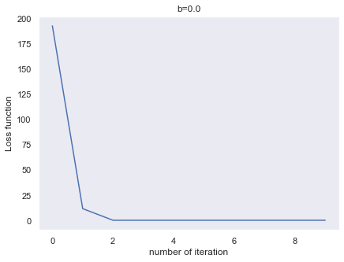

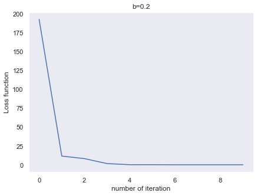

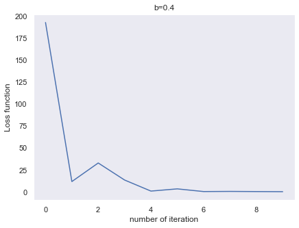

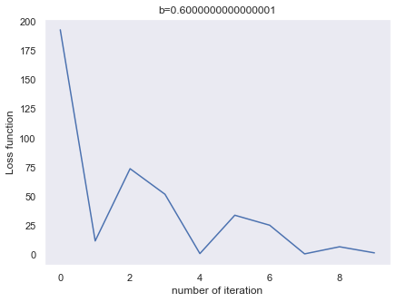

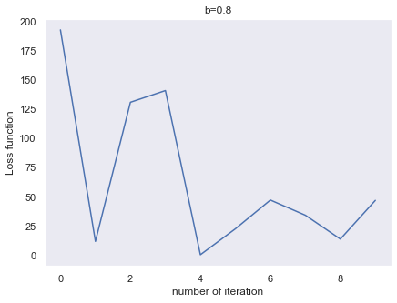

```python
for b in np.arange(0, 1, 0.2):
    hist, x_opt, X = Momentum_SGD(f, df, x0=5.0, alpha=1/L, beta=b, Nsteps=10)
    fig = plt.figure(figsize = (15,5))
    ax = plt.subplot(121)
    ax.plot(range(len(hist)), hist, label=f"$\beta$={b}")
    ax.set_ylabel('Loss function')
    ax.set_xlabel('number of iteration')
    ax.grid()
    # ax.legend(loc = 'best')
    ax.set_title(f"b={b}")
    print(x_opt)
```

Выводы из этого делаю такие: при больших $\beta$ тяжёлый шарик начинает больше учитывать значение на предыдущем шаге. Поэтому на первых шагах не уменьшает лосс, а наоборот увеличивает и обычный градиентный спуск работает тут гораздо лучше и легко находит глобальный минимум не упераясь в локальный. Но давайте возьмём $\alpha $ поменьше

```
1.7210330712334105
1.3056779947172839
0.686163038209825
0.1728686238203956
0.0020601896136340715
```

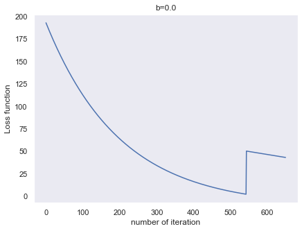

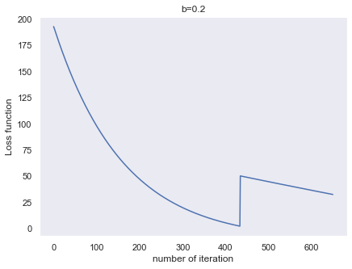

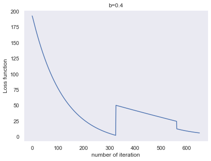

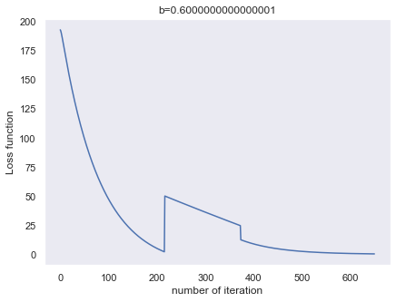

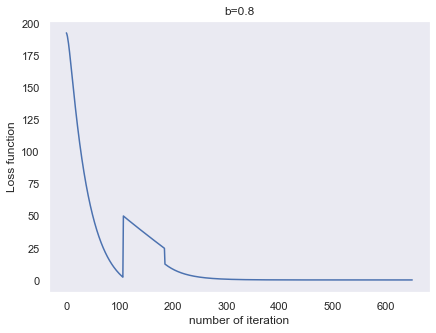

```python
for b in np.arange(0, 1, 0.2):
    hist, x_opt, X = Momentum_SGD(f, df, x0=5.0, alpha=0.0001, beta=b, Nsteps=650)
    fig = plt.figure(figsize = (15,5))
    ax = plt.subplot(121)
    ax.plot(range(len(hist)), hist, label=f"$\beta$={b}")
    ax.set_ylabel('Loss function')
    ax.set_xlabel('number of iteration')
    ax.grid()
    # ax.legend(loc = 'best')
    ax.set_title(f"b={b}")
    print(x_opt)
```

Для такого маленького $\alpha$ при большем $\beta$ сходимость будет намного быстрее (мы делаем маленькие шажки в одном и том же направлении, поэтому учитывая предыдущий шаг (ускорение), мы спускаемся быстрее)